# MasterControl EDA

# 1 Introduction

MasterControl’s Manufacturing Solutions product (Mx) is significantly underperforming its Quality Solutions product (Qx). The company believes it may not be targeting the right companies or the right people within those companies, leading to missed revenue opportunities and wasted marketing expenditures.

Conversion predictions will be generated using a classification model. The model will use historical sale leads and data collected from MasterControl. Then we will analyze patterns produced by the models to identify similarities between higher-converting accounts.

The purpose of this EDA notebook is to explore the relationships between different variables in the data. We will explore questions like what are the common characteristics of contacts/companies that are best prospects for Mx and how they differ from Qx products.

# 2 Description of the data

```r
# Import packages
suppressMessages(suppressWarnings({
library(tidyverse)
library(dplyr)
library(stringr)
library(ggplot2)
  }))

# Import csv file
master <- read.csv("Mastercontrol QAL Performance.csv")

# Quick look at the data
master |>
  str()
```

```
## 'data.frame':    16644 obs. of  14 variables:
##  $ acct.primary.site.function  : chr  "Food and beverage" "Surgical instruments" "Cell therapies (CAR-T, NK)" "In-vitro diagnostic (IVD) kits" ...
##  $ acct.manufacturing.model    : chr  "Consumer Packaged Goods" "In-House" "Hospital Investigational Drug Unit" "In-House" ...
##  $ acct.target.industry        : chr  "Non-Life Science" "Medical Device" "Blood & Biologics" "Medical Device" ...
##  $ contact.lead.title          : chr  "QA Manager" "Quality Manager" "ING" "Sr. Director of IT" ...
##  $ QAL.ID                      : chr  "a0dPQ000005WbfuYAC" "a0dPQ00000CRpkLYAT" "a0dPQ000000KWdFYAW" "a0dPQ000004LOWTYA4" ...
##  $ contact.lead.id             : chr  "0030c00002XPeNGAA1" "0030c00002ZaC9pAAF" "0030c00002ZzekAAAR" "0030c00002a0E0cAAE" ...
##  $ next_stage__c               : chr  "SQL" "Won" "Recycled" "Recycled" ...
##  $ Priority                    : chr  "P1 - Webinar Demo" "Priority 2" "Priority 2" "P1 - Webinar Demo" ...
##  $ acct.territory.rollup       : chr  "Americas" "Americas" "EMEA" "Americas" ...
##  $ acct.tier.rollup            : chr  "Medium" "Medium" "Large" "Medium" ...
##  $ solution                    : chr  "Mx" "Mx" "Qx" "Logbooks" ...
##  $ solution_rollup             : chr  "Mx" "Mx" "Qx" "Mx" ...
##  $ last.tactic.campaign.channel: chr  "Online Ads" "SEO" "Email" "External Demand Gen" ...
##  $ qal.cohort.date             : chr  "2025-06-16" "2025-11-13" "2024-02-15" "2025-04-29" ...
```

```r
master |>
  summary()
```

```
##  acct.primary.site.function acct.manufacturing.model acct.target.industry
##  Length:16644               Length:16644             Length:16644
##  Class :character           Class :character         Class :character
##  Mode  :character           Mode  :character         Mode  :character
##  contact.lead.title    QAL.ID          contact.lead.id    next_stage__c
##  Length:16644       Length:16644       Length:16644       Length:16644
##  Class :character   Class :character   Class :character   Class :character
##  Mode  :character   Mode  :character   Mode  :character   Mode  :character
##    Priority         acct.territory.rollup acct.tier.rollup     solution
##  Length:16644       Length:16644          Length:16644       Length:16644
##  Class :character   Class :character      Class :character   Class :character
##  Mode  :character   Mode  :character      Mode  :character   Mode  :character
##  solution_rollup    last.tactic.campaign.channel qal.cohort.date
##  Length:16644       Length:16644                 Length:16644
##  Class :character   Class :character             Class :character
##  Mode  :character   Mode  :character             Mode  :character
```

```r
# Checking the proportion of each target variable value
prop.table(table(master$next_stage__c))
```

```
##
##                   Exclude          INQ         Lost          MQL     Recycled
## 0.0236721942 0.0732396059 0.0001201634 0.0007209805 0.0006008171 0.7221220860
##          SQL          SQO          Won
## 0.1618601298 0.0152607546 0.0024032684
```

Right now, qal.cohort.date is stored as characters, we will have to convert this to a date format.

```r
master$qal.cohort.date <- ymd(master$qal.cohort.date)
```

# 3 Discussion of missing data

```r
# Checking for blanks in each column
NA_col <- colSums(master == "", na.rm = TRUE)

# Check total blanks across all data
NA_total <- sum(master == "", na.rm = TRUE)

NA_col
```

```
##   acct.primary.site.function     acct.manufacturing.model
##                           60                          101
##         acct.target.industry           contact.lead.title
##                           45                         4860
##                       QAL.ID              contact.lead.id
##                            0                            3
##                next_stage__c                     Priority
##                          394                            0
##        acct.territory.rollup             acct.tier.rollup
##                          132                           45
##                     solution              solution_rollup
##                            0                            0
## last.tactic.campaign.channel              qal.cohort.date
##                            0                            0
```

```r
NA_total
```

```
## [1] 5640
```

There are 8 variables that have blank values, and a total of 5,640 cells that were left blank.

### 3.0.1 Converting blanks to NA

We have identified the blanks so now we can convert them to NA.

```r
master_clean <- master |>
  mutate(across(where(is.character), ~ na_if(., "")))

# Check for blanks again
colSums(master_clean == "", na.rm = TRUE)
```

```
##   acct.primary.site.function     acct.manufacturing.model
##                            0                            0
##         acct.target.industry           contact.lead.title
##                            0                            0
##                       QAL.ID              contact.lead.id
##                            0                            0
##                next_stage__c                     Priority
##                            0                            0
##        acct.territory.rollup             acct.tier.rollup
##                            0                            0
##                     solution              solution_rollup
##                            0                            0
## last.tactic.campaign.channel              qal.cohort.date
##                            0                            0
```

```r
# Calculating the percent of NAs in each column
master_clean |>
  summarise(across(everything(),
                   ~ round(mean(is.na(.)) * 100, 2)))
```

```
##   acct.primary.site.function acct.manufacturing.model acct.target.industry
## 1                       0.36                     0.61                 0.27
##   contact.lead.title QAL.ID contact.lead.id next_stage__c Priority
## 1              29.21      0            0.02          2.37        0
##   acct.territory.rollup acct.tier.rollup solution solution_rollup
## 1                  0.79             0.27        0               0
##   last.tactic.campaign.channel qal.cohort.date
## 1                            0               0
```

acct.primary.site.function, acct.manufacturing.model, acct.target.industry, contact.lead.id, next_stage__c, acct.territory.rollup, and acct.tier.rollup all have less than 3% NAs. We can delete these since they make up such a miniscule amount.

```r
master_clean <- master_clean |>
  filter(!is.na(acct.primary.site.function),
         !is.na(acct.manufacturing.model),
         !is.na(acct.target.industry),
         !is.na(contact.lead.id),
         !is.na(next_stage__c),
         !is.na(acct.territory.rollup),
         !is.na(acct.tier.rollup))

# Checking to see if NAs were dropped in those columns
master_clean |>
  summarise(across(everything(),
                   ~ round(mean(is.na(.)) * 100, 2)))
```

```
##   acct.primary.site.function acct.manufacturing.model acct.target.industry
## 1                          0                        0                    0
##   contact.lead.title QAL.ID contact.lead.id next_stage__c Priority
## 1              28.88      0               0             0        0
##   acct.territory.rollup acct.tier.rollup solution solution_rollup
## 1                     0                0        0               0
##   last.tactic.campaign.channel qal.cohort.date
## 1                            0               0
```

contact.lead.title has 28.88% of its data NAs. Since this is such a large amount, we will keep these rows because they could still hold valuable information. There are no numeric values in the dataset so we can convert NA to “Missing” instead for categorical analysis.

```r
master_clean <- master_clean |>
  mutate(across(where(~ is.character(.)),
                ~ ifelse(is.na(.), "Missing", as.character(.))))

# Checking NAs
master_clean |>
  summarise(across(everything(),
                   ~ round(mean(is.na(.)) * 100, 2)))
```

```
##   acct.primary.site.function acct.manufacturing.model acct.target.industry
## 1                          0                        0                    0
##   contact.lead.title QAL.ID contact.lead.id next_stage__c Priority
## 1                  0      0               0             0        0
##   acct.territory.rollup acct.tier.rollup solution solution_rollup
## 1                     0                0        0               0
##   last.tactic.campaign.channel qal.cohort.date
## 1                            0               0
```

Now there are no NAs in the dataset. They have been replaced by “Missing” instead and we will treat them as its own category.

### 3.0.2 Grouping unique values to larger categories

Another important thing about this dataset is that there are many unique values for each column. This creates high cardinality and can make it hard for us to model our data. We will group these categories into larger groups to make them more meaningful.

```r
# Grouping SQL, SQO, and Won as Success and the rest as Failure
master_clean <- master_clean |>
  mutate(success_binary = ifelse(
    next_stage__c %in% c("SQL", "SQO", "Won"),
    1,
    0
  ))

# Checking class balance
prop.table(table(master_clean$success_binary))
```

```
##
##        0        1
## 0.815193 0.184807
```

```r
# Converting all contact lead titles to uppercase for standardization
master_clean <- master_clean |>
  mutate(contact.lead.title = str_trim(contact.lead.title),
         contact.lead.title = str_to_upper(contact.lead.title))

# Grouping contact lead titles to more general categories
master_clean <- master_clean |>
  mutate(title_group = case_when(
    str_detect(contact.lead.title, "CHIEF|CEO|CFO|CTO|COO|CIO|PRESIDENT|OWNER|FOUNDER|EXECUTIVE|DIR") ~ "Executive",
    str_detect(contact.lead.title, "VP|VICE PRESIDENT|HEAD") ~ "VP / Head",
    str_detect(contact.lead.title, "DIRECTOR") ~ "Director",
    str_detect(contact.lead.title, "MANAGER|SUPERVISOR|MANAGE|MANGER") ~ "Manager",
    str_detect(contact.lead.title, "ENGINEER|SCIENTIST|TECHNICAL|DEVELOPER|LEAD|TECHNICIAN|ARCHITECT") ~ "Technical",
    str_detect(contact.lead.title, "ANALYST") ~ "Analyst",
    str_detect(contact.lead.title, "SPECIALIST|ASSOCIATE|COORDINATOR") ~ "Specialist",
    str_detect(contact.lead.title, "CONSULTANT|CONSULTING") ~ "Consultant",
    str_detect(contact.lead.title, "MISSING") ~ "Unknown",
    str_detect(contact.lead.title, "PROFESSOR|RESEARCHER|RESEARCH|LECTURER|TEACHER|PROF") ~ "Academia",
    str_detect(contact.lead.title, "SALES") ~ "Sales",
    TRUE ~ "Other"
  ))

# Checking title group distribution
prop.table(table(master_clean$title_group))
```

```
##
##    Academia     Analyst  Consultant   Executive     Manager       Other
## 0.005230386 0.009962640 0.016749689 0.199688667 0.225404732 0.077957659
##       Sales  Specialist   Technical     Unknown   VP / Head
## 0.002366127 0.044209215 0.086052304 0.288792030 0.043586550
```

```r
# Converting all primary site functions to uppercase for standardization
master_clean <- master_clean |>
  mutate(acct.primary.site.function = str_trim(acct.primary.site.function),
         acct.primary.site.function = str_to_upper(acct.primary.site.function))

# Grouping acct primary site function
master_clean <- master_clean |>
  mutate(site_function = case_when(
    str_detect(acct.primary.site.function, "OSD|STERILE INJECTABLES|API|BIOLOGICS|CELL THERAPIES") ~ "Active Pharma Manufacturing",
    str_detect(acct.primary.site.function, "IMPLANTABLE DEVICES|IVD|INSTRUMENTS|PHARMA|HEALTH|MEDICAL|SURGICAL|PATIENT|DRUG|CARE|DIAGNOSTIC|BLOOD|VACCINE") ~ "Medical Device Manufacturing",
    str_detect(acct.primary.site.function, "SERVICES|CONSULTING|NON-MANUFACTURING") ~ "Non-Manufacturing",
    str_detect(acct.primary.site.function, "FOOD|BEVERAGE|NUTRACEUTICAL|COSMETICS|CHEMICALS") ~ "Other Manufacturing",
    str_detect(acct.primary.site.function, "NOT ENOUGH INFO FOUND|MISSING") ~ "Unknown",
    TRUE ~ "Other"
  ))

prop.table(table(master_clean$site_function))
```

```
##
##  Active Pharma Manufacturing Medical Device Manufacturing
##                   0.11811955                   0.19134496
##            Non-Manufacturing                        Other
##                   0.33100872                   0.14396015
##          Other Manufacturing                      Unknown
##                   0.06058531                   0.15498132
```

# 4 Exploratory visualizations and /or summary tables

```r
table(master_clean$success_binary)
```

```
##
##     0     1
## 13092  2968
```

```r
prop.table(table(master_clean$success_binary))
```

```
##
##        0        1
## 0.815193 0.184807
```

```r
# Distinction between Mx and Qx successes
master_clean |>
  group_by(solution_rollup) |>
  summarise(
    total = n(),
    successes = sum(success_binary),
    success_rate = mean(success_binary)
  )
```

```
## # A tibble: 2 × 4
##   solution_rollup total successes success_rate
##   <chr>           <int>     <dbl>        <dbl>
## 1 Mx               4040       524        0.130
## 2 Qx              12020      2444        0.203
```

Within Mx solutions alone, we have a success rate of 12.9% while Qx has 20.3%, which is expected.

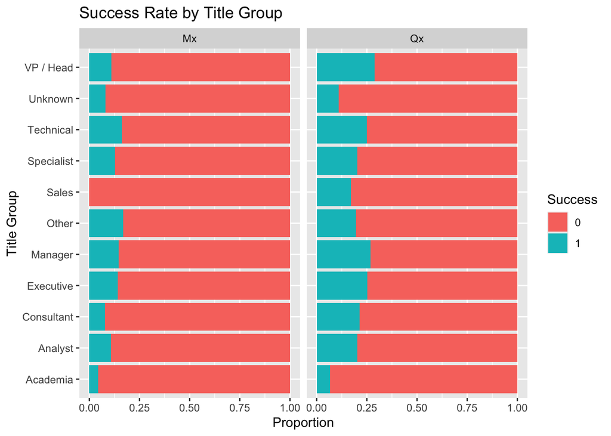

```r
master_clean |>
  ggplot(aes(x = title_group, fill = factor(success_binary))) +
  geom_bar(position = "fill") +
  coord_flip() +
  facet_wrap(~ solution_rollup) +
  labs(fill = "Success",
       x = "Title Group",
       y = "Proportion",
       title = "Success Rate by Title Group")
```

A lot of the contact lead titles were left blank so there are many Unknowns that make up a lot of the data. If we ignore that category though, we see that many of the successes are from Manager/Executive roles. The next best category are Technical roles.

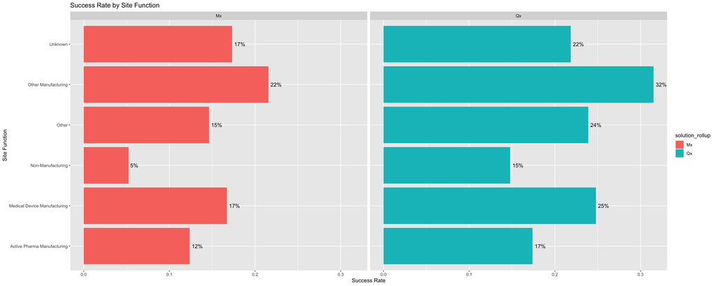

```r
master_clean |>
  group_by(site_function, solution_rollup) |>
  summarise(success_rate = mean(success_binary, na.rm = TRUE)) |>
  ggplot(aes(x = site_function, y = success_rate, fill = solution_rollup)) +
  geom_col() +
  geom_text(aes(label = scales::percent(success_rate, accuracy = 1)), hjust = -0.2) +
  coord_flip() +
  facet_wrap(~ solution_rollup) +
  labs(
    x = "Site Function",
    y = "Success Rate",
    title = "Success Rate by Site Function"
  )
```

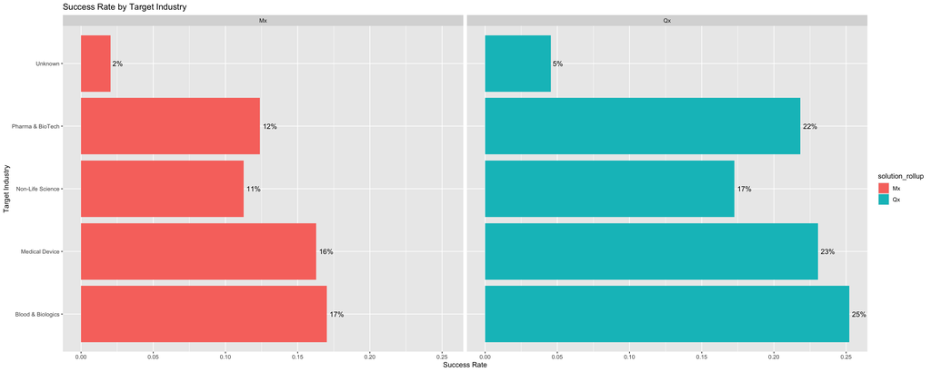

```r
master_clean |>
  group_by(acct.target.industry, solution_rollup) |>
  summarise(success_rate = mean(success_binary, na.rm = TRUE), .groups = "drop") |>
  ggplot(aes(x = acct.target.industry, y = success_rate, fill = solution_rollup)) +
  geom_col() +
  geom_text(aes(label = scales::percent(success_rate, accuracy = 1)), hjust = -0.2) +
  coord_flip() +
  facet_wrap(~ solution_rollup) +
  labs(
    x = "Target Industry",
    y = "Success Rate",
    title = "Success Rate by Target Industry"
  )
```

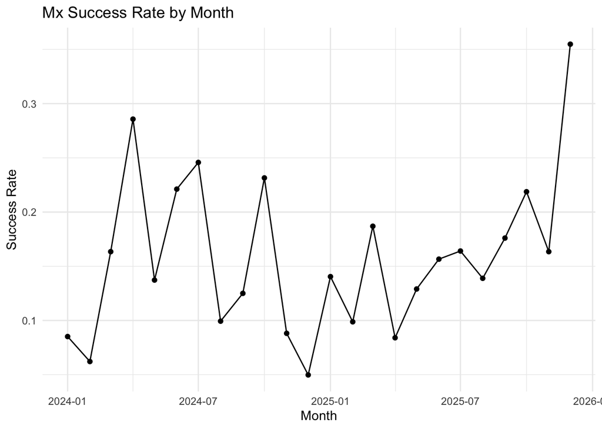

```r
# Creating a month variable
master_clean <- master_clean |>
  mutate(month = floor_date(qal.cohort.date, "month"))

# Success rate by month filtered to only Mx products
master_clean |>
  filter(solution_rollup == "Mx") |>
  group_by(month) |>
  summarise(
    total = n(),
    success_rate = mean(success_binary)
  ) |>
  ggplot(aes(x = month, y = success_rate)) +
  geom_line() +
  geom_point() +
  labs(title = "Mx Success Rate by Month",
       x = "Month",
       y = "Success Rate") +
  theme_minimal()
```

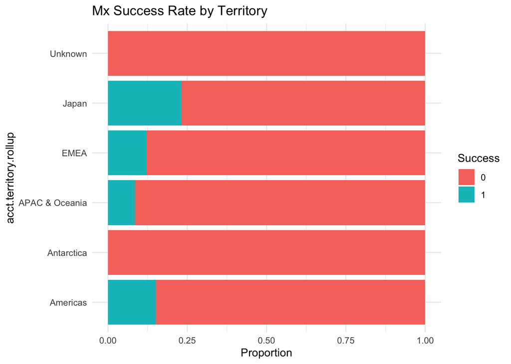

```r
master_clean |>
  filter(solution_rollup == "Mx") |>
  ggplot(aes(x = acct.territory.rollup, fill = factor(success_binary))) +
  geom_bar(position = "fill") +
  coord_flip() +
  labs(title = "Mx Success Rate by Territory",
       y = "Proportion",
       fill = "Success") +
  theme_minimal()
```

Mx products predominately show successes in Japan and the Americas, with lower presence in EMEA and APAC/Oceania markets.

# 5 Results

Although our EDA highlights key trends within the data, there is still a substantial portion where there are missing/unknown values. This limits the insights we can draw from this and we will have to take this in consideration as we move forward into the modeling part of our project.